# PeMS traffic flow over OpenStreetMap roads: 16 June 2026

The example contains 16 June 2026 from the PeMS hourly FLOW product covering January 2020 to June 2026. All 24 saved hourly rows and 4,435 display links are retained. The default map shows 16:00 over an offline OSM basemap of roads, water and place labels.

## Source and data preparation

The source map is `la_area_freeway_volume_2020_01_to_2026_06.html`; the June array is `flow_2026_06.binz`. Data preparation selects zero-based monthly rows 360 through 383, corresponding to 00:00 through 23:00 on 16 June. Integer flow values and the original network mappings are serialized into compressed JSON. The source rows already contain hourly totals, so this stage does not aggregate raw observations.

```r
source('pems-flow.R')
prepare_pems_flow(
  html_file='la_area_freeway_volume_2020_01_to_2026_06.html',
  flow_file='flow_2026_06.binz',
  file='data/pems-flow.json.gz')
```

`prepare_pems_flow()` records source checksums and the exact row slice. The original upstream `build_flow_assets.py` constructs monthly hourly arrays from cleaned district-month flow CSVs and retains active network positions. The saved map then averages positions within stations and endpoint stations within display links.

Basemap preparation uses `download_osm.py`. The script reads the flow network’s bounds with a 0.03 degree margin, selects zoom-9 tiles from the Protomaps build dated 2026-10-20, and extracts the `roads`, `water` and `places` layers. The cache contains tile hashes, source metadata, retrieval time and a geometry checksum in the same compressed file as the geometry. Python dependencies are `requests`, `pmtiles` and `mapbox-vector-tile`. The cached basemap is a contemporary display layer, not a reconstruction of the June road network or a routing graph.

## Saved fields

```r
snapshot <- read_pems_flow(params$snapshot)
osm <- read_pems_osm(params$basemap)
frame <- pems_flow_frame(snapshot, time_index=params$time_index)
knitr::kable(data.frame(
  item=c('Date','Hourly frames','Fixed stations','Fixed positions',
         'Active source columns','Display links','Selected daily frame','Timestamp'),
  value=c(snapshot$date,nrow(snapshot$flow),snapshot$stationCount,
          length(snapshot$positionStations),ncol(snapshot$flow),length(snapshot$links),
          frame$time_index,frame$timestamp)))
```

| item | value |
| --- | --- |
| Date | 2026-06-16 |
| Hourly frames | 24 |
| Fixed stations | 4307 |
| Fixed positions | 5065 |
| Active source columns | 4112 |
| Display links | 4435 |
| Selected daily frame | 17 |
| Timestamp | 2026-06-16 16:00 |

The LA-area network covers the saved D07, D08 and D12 district links. It contains 4,307 stations and 5,065 fixed positions. June has 4,112 active source columns. All 4,435 display links remain present, including links without available endpoint values.

| Field | Definition |
| --- | --- |
| `schema_version`, `source`, `provenance` | Payload version, `pems-flow` identifier and source records. |
| `date`, `timeLabels`, `stepMinutes` | One day, 24 consecutive source-clock labels and 60-minute spacing. |
| `flowByHour` | Original integer values in June’s source-column order. |
| `segmentPositions`, `positionStations` | Source column to fixed position, then fixed position to station ID. |
| `links` | Original ordered link IDs, endpoints, directions and coordinates. |
| `missingValue` | Missing sentinel 65535; zero is valid flow. |

The reader averages available active positions within each station, then the available endpoint station values for each link. A link with one available endpoint uses that value; a link with neither endpoint available remains missing. Fractional endpoint means are retained.

## Traffic flow in geographic context

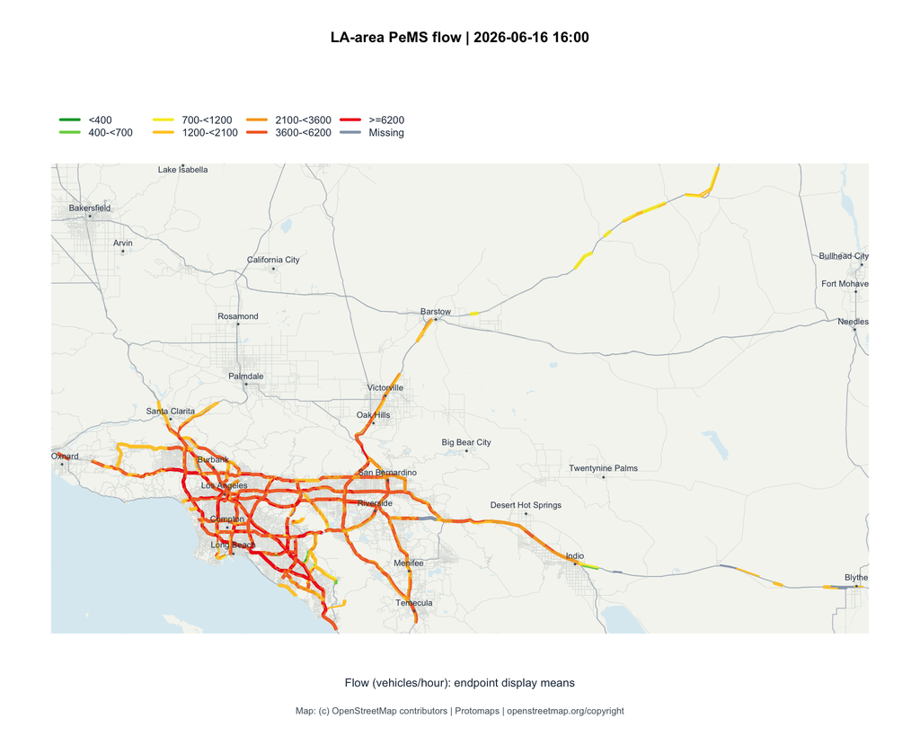

```r
pems_flow_plot(frame, osm)
```

Gray background roads, blue water and place labels come from the cached OSM extract. Colored links retain their source coordinates and directional display offsets at the saved initial zoom. The display links join freeway stations; the background does not map-match them or alter their flow values.

The seven-color palette uses thresholds of 400, 700, 1,200, 2,100, 3,600 and 6,200 vehicles/hour. Equality enters the higher class. The source’s monotone `log1p` transformation leaves these class boundaries unchanged. Gray flow links indicate missing values; valid zero flow remains green.

Daily R indices run from 1 to 24. The selected 16:00 frame is index 17 here, index 377 in the original June array, and JavaScript index 376.

## Daily coverage

```r
stopifnot(nrow(snapshot$flow)==24L,
          identical(snapshot$timeLabels,paste('2026-06-16',sprintf('%02d:00',0:23))))
knitr::kable(data.frame(
  position_hour_values=length(snapshot$flow),
  missing_sentinels=sum(snapshot$flow==snapshot$missingValue),
  valid_zeros=sum(snapshot$flow==0L),
  selected_links_with_values=sum(is.finite(frame$links$volume)),
  selected_links_without_values=sum(!is.finite(frame$links$volume))))
```

| position_hour_values | missing_sentinels | valid_zeros | selected_links_with_values | selected_links_without_values |
| --- | --- | --- | --- | --- |
| 98688 | 0 | 101 | 4379 | 56 |

The slice contains 98,688 position-hour values, including 101 valid zeros and no missing sentinels. This count concerns the active source columns, not all fixed network positions. The original hourly extractor sums available five-minute TotalFlow records without scaling incomplete hours to twelve intervals. Valid encoded values are capped at 65534. The flow payload does not contain contributing-interval counts, so a present value does not certify complete raw observation coverage.

Hour labels follow the source viewer’s UTC arithmetic, which creates evenly spaced rows across daylight-saving transitions. This preserves the saved labels without establishing a conversion of the raw measurements’ timezone.

## Frame selection and export

The `time_index` parameter selects an hour within the saved day. Frame 9 is 08:00. The export function uses the same cached basemap and flow workflow:

```r
pems_flow_figures(params$snapshot, time_index=9L,
                   output_dir='output/pems-20260616-0800')
```

Exports contain PDF and PNG figures, the selected frame as RDS, link values as CSV and source records. Rendering depends on `jsonlite`, `rmarkdown`, `knitr` and Pandoc. Preparation also uses `digest`. The saved flow and OSM cache provide all map inputs during rendering.

## Sources and interpretation

Traffic source records identify the original map, June array and exact daily slice. Basemap records identify the Protomaps archive and individual tiles. The OSM source is dated 20 October 2026; the traffic day is 16 June 2026.

Map data: [OpenStreetMap contributors](https://www.openstreetmap.org/copyright). The [Protomaps basemap](https://docs.protomaps.com/basemaps/downloads) is an OSM-derived ODbL Produced Work. Zoom-9 geometry is generalized and split at tile boundaries. It supplies geographic context rather than routing connectivity.

Display-link endpoint means are dependent observations and cannot be summed as independent traffic totals. Individual vehicle paths, speed reductions and causal congestion origins are not identified by this flow payload.